# Live coding 4

Andrew Irwin

2021-01-28 8:35

# Agenda

- Questions arising from lessons, tasks
- Examples from lessons 9, 10, 11: summarizing data, making facetted plots, reading files

The plan for the live coding is for us to work together to solve problems using tools from this week’s lesson. As with last week, we’ll start with some repeated examples from lessons to remind ourselves of the basics, then try to use the tools in new ways, and finally switch perspectives to try to solve a real problem with each tool.

## Summarizing data

These tools are in the `dplyr` package. There are lots of functions (look in the help for the package dplyr), but we have focussed on four: `filter`, `group_by`, `mutate`, and `summarise`. These tools allow you to manipulate a large dataset to extract information.

Let’s use the penguin data from palmerpenguins (see the setup code block starting at line 8.)

Before we start, familiarize yourself with the data by typing `View(penguins)` or `glimpse(penguins)` into the console.

### filter

Let’s get only the rows of Adelie penguins from Biscoe island.

```r
penguins %>% filter(species == "Adelie" & island == "Biscoe")
```

```
## # A tibble: 44 x 8
##    species island bill_length_mm bill_depth_mm flipper_length_… body_mass_g
##    <fct>   <fct>           <dbl>         <dbl>            <int>       <int>
##  1 Adelie  Biscoe           37.8          18.3              174        3400
##  2 Adelie  Biscoe           37.7          18.7              180        3600
##  3 Adelie  Biscoe           35.9          19.2              189        3800
##  4 Adelie  Biscoe           38.2          18.1              185        3950
##  5 Adelie  Biscoe           38.8          17.2              180        3800
##  6 Adelie  Biscoe           35.3          18.9              187        3800
##  7 Adelie  Biscoe           40.6          18.6              183        3550
##  8 Adelie  Biscoe           40.5          17.9              187        3200
##  9 Adelie  Biscoe           37.9          18.6              172        3150
## 10 Adelie  Biscoe           40.5          18.9              180        3950
## # … with 34 more rows, and 2 more variables: sex <fct>, year <int>
```

Now get all the rows that are either Adelies OR are on Biscoe Island.

```r
penguins %>% filter(species == "Adelie" | island == "Biscoe")
```

```
## # A tibble: 276 x 8
##    species island bill_length_mm bill_depth_mm flipper_length_… body_mass_g
##    <fct>   <fct>           <dbl>         <dbl>            <int>       <int>
##  1 Adelie  Torge…           39.1          18.7              181        3750
##  2 Adelie  Torge…           39.5          17.4              186        3800
##  3 Adelie  Torge…           40.3          18                195        3250
##  4 Adelie  Torge…           NA            NA                 NA          NA
##  5 Adelie  Torge…           36.7          19.3              193        3450
##  6 Adelie  Torge…           39.3          20.6              190        3650
##  7 Adelie  Torge…           38.9          17.8              181        3625
##  8 Adelie  Torge…           39.2          19.6              195        4675
##  9 Adelie  Torge…           34.1          18.1              193        3475
## 10 Adelie  Torge…           42            20.2              190        4250
## # … with 266 more rows, and 2 more variables: sex <fct>, year <int>
```

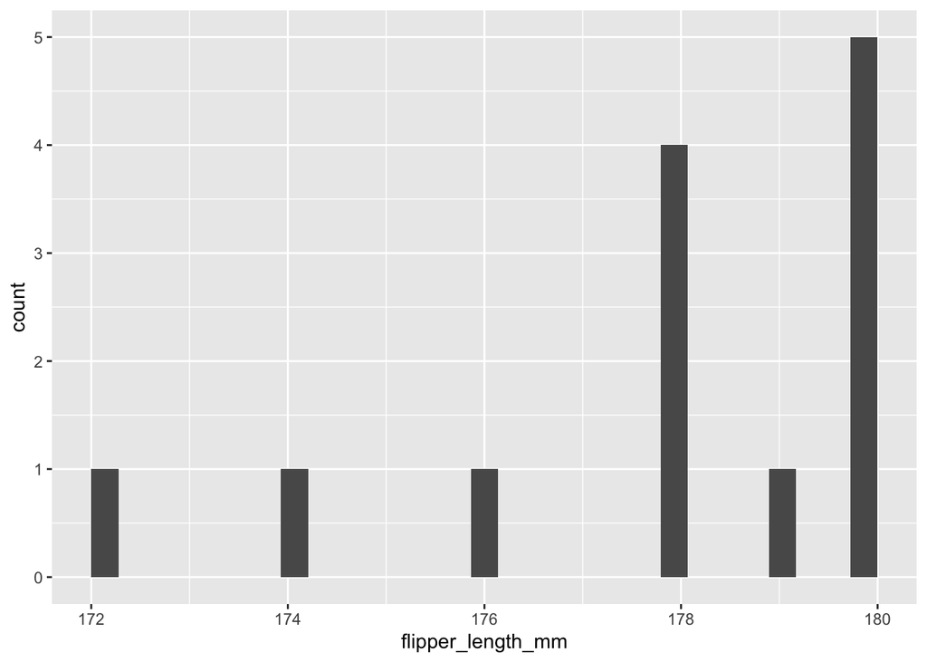

```r
penguins %>% filter(!(flipper_length_mm  > 180)) %>%
  ggplot(aes(x=flipper_length_mm)) + geom_histogram()
```

### mutate

Mutate adds a new variable to each row.

Compute a “bill to flipper ratio” equal to the bill length divided by flipper length.

```r
penguins %>% mutate(bill_flipper_ratio = bill_length_mm / flipper_length_mm)
```

```
## # A tibble: 344 x 9
##    species island bill_length_mm bill_depth_mm flipper_length_… body_mass_g
##    <fct>   <fct>           <dbl>         <dbl>            <int>       <int>
##  1 Adelie  Torge…           39.1          18.7              181        3750
##  2 Adelie  Torge…           39.5          17.4              186        3800
##  3 Adelie  Torge…           40.3          18                195        3250
##  4 Adelie  Torge…           NA            NA                 NA          NA
##  5 Adelie  Torge…           36.7          19.3              193        3450
##  6 Adelie  Torge…           39.3          20.6              190        3650
##  7 Adelie  Torge…           38.9          17.8              181        3625
##  8 Adelie  Torge…           39.2          19.6              195        4675
##  9 Adelie  Torge…           34.1          18.1              193        3475
## 10 Adelie  Torge…           42            20.2              190        4250
## # … with 334 more rows, and 3 more variables: sex <fct>, year <int>,
## #   bill_flipper_ratio <dbl>
```

```r
penguins %>% mutate(bill_flipper_ratio_max = max(bill_length_mm / flipper_length_mm, na.rm=TRUE))
```

```
## # A tibble: 344 x 9
##    species island bill_length_mm bill_depth_mm flipper_length_… body_mass_g
##    <fct>   <fct>           <dbl>         <dbl>            <int>       <int>
##  1 Adelie  Torge…           39.1          18.7              181        3750
##  2 Adelie  Torge…           39.5          17.4              186        3800
##  3 Adelie  Torge…           40.3          18                195        3250
##  4 Adelie  Torge…           NA            NA                 NA          NA
##  5 Adelie  Torge…           36.7          19.3              193        3450
##  6 Adelie  Torge…           39.3          20.6              190        3650
##  7 Adelie  Torge…           38.9          17.8              181        3625
##  8 Adelie  Torge…           39.2          19.6              195        4675
##  9 Adelie  Torge…           34.1          18.1              193        3475
## 10 Adelie  Torge…           42            20.2              190        4250
## # … with 334 more rows, and 3 more variables: sex <fct>, year <int>,
## #   bill_flipper_ratio_max <dbl>
```

Compute a scaled bill to flipper ratio, so that the maximum ratio is 1.

```r
penguins %>% mutate(bill_flipper_ratio_scaled = (bill_length_mm / flipper_length_mm) / max(bill_length_mm / flipper_length_mm, na.rm=TRUE))
```

```
## # A tibble: 344 x 9
##    species island bill_length_mm bill_depth_mm flipper_length_… body_mass_g
##    <fct>   <fct>           <dbl>         <dbl>            <int>       <int>
##  1 Adelie  Torge…           39.1          18.7              181        3750
##  2 Adelie  Torge…           39.5          17.4              186        3800
##  3 Adelie  Torge…           40.3          18                195        3250
##  4 Adelie  Torge…           NA            NA                 NA          NA
##  5 Adelie  Torge…           36.7          19.3              193        3450
##  6 Adelie  Torge…           39.3          20.6              190        3650
##  7 Adelie  Torge…           38.9          17.8              181        3625
##  8 Adelie  Torge…           39.2          19.6              195        4675
##  9 Adelie  Torge…           34.1          18.1              193        3475
## 10 Adelie  Torge…           42            20.2              190        4250
## # … with 334 more rows, and 3 more variables: sex <fct>, year <int>,
## #   bill_flipper_ratio_scaled <dbl>
```

### summarise

Summarize creates new variables, but instead of giving a value for each row, it computes functions that convert many values into a single one, like `mean` or `n`. Without grouping, you get just one summary value for the whole table. With grouping you get one row for each combination of levels of each grouped variable. We’ll practice without grouping at first.

Count the number of rows in the penguins dataset using the `n` function.

```r
penguins %>% summarize(count = n())
```

```
## # A tibble: 1 x 1
##   count
##   <int>
## 1   344
```

Compute the minimum, mean, and maximum body mass of all the penguins.

```r
penguins %>% summarize(min_bm = min(body_mass_g, na.rm=TRUE),
                       max_bm = max(body_mass_g, na.rm=TRUE),
                       mean_bm = mean(body_mass_g, na.rm=TRUE)
                       )
```

```
## # A tibble: 1 x 3
##   min_bm max_bm mean_bm
##    <int>  <int>   <dbl>
## 1   2700   6300   4202.
```

### group_by

`group_by` divides a data frame (tibble, data table) according to the levels of a categorical variable. This will affect how summarize works and how functions like max and mean work by dividing the data into non-overlapping sets, computing the functions, and then combining the parts into a single table.

Repeat the calculations using summarize we wrote above, but use group_by on species, island, or both.

```r
penguins %>% group_by(species, island) %>% summarize(count = n(),
                                             min_bm = min(body_mass_g, na.rm=TRUE),
                                             mean_bm = mean(body_mass_g, na.rm=TRUE)
                                             )
```

```
## # A tibble: 5 x 5
## # Groups:   species [3]
##   species   island    count min_bm mean_bm
##   <fct>     <fct>     <int>  <int>   <dbl>
## 1 Adelie    Biscoe       44   2850   3710.
## 2 Adelie    Dream        56   2900   3688.
## 3 Adelie    Torgersen    52   2900   3706.
## 4 Chinstrap Dream        68   2700   3733.
## 5 Gentoo    Biscoe      124   3950   5076.
```

You can also use group_by with filter and mutate.

Compute the maximum body mass for each penguin species, put that in a new variable, then compute the body mass divided by the maximum body mass.

```r
penguins %>% group_by(species) %>%
  mutate(bm_max = max(body_mass_g, na.rm=TRUE),
         bm_scaled = body_mass_g / max(body_mass_g, na.rm=TRUE))
```

```
## # A tibble: 344 x 10
## # Groups:   species [3]
##    species island bill_length_mm bill_depth_mm flipper_length_… body_mass_g
##    <fct>   <fct>           <dbl>         <dbl>            <int>       <int>
##  1 Adelie  Torge…           39.1          18.7              181        3750
##  2 Adelie  Torge…           39.5          17.4              186        3800
##  3 Adelie  Torge…           40.3          18                195        3250
##  4 Adelie  Torge…           NA            NA                 NA          NA
##  5 Adelie  Torge…           36.7          19.3              193        3450
##  6 Adelie  Torge…           39.3          20.6              190        3650
##  7 Adelie  Torge…           38.9          17.8              181        3625
##  8 Adelie  Torge…           39.2          19.6              195        4675
##  9 Adelie  Torge…           34.1          18.1              193        3475
## 10 Adelie  Torge…           42            20.2              190        4250
## # … with 334 more rows, and 4 more variables: sex <fct>, year <int>,
## #   bm_max <int>, bm_scaled <dbl>
```

What about group_by and filter?

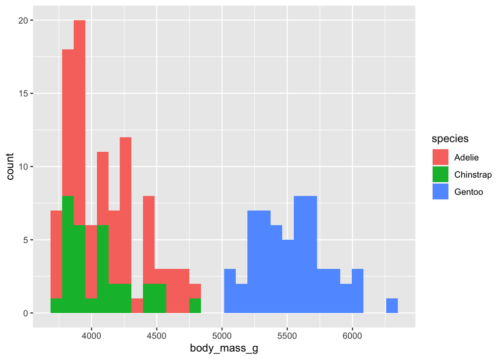

```r
penguins %>% group_by(species) %>%  filter( body_mass_g > mean(body_mass_g, na.rm=TRUE)) %>%
  ggplot(aes(x=body_mass_g, fill=species))  + geom_histogram()
```

There are lots of other useful functions here – like lead, lag, dense_rank, etc. See `?mutate`.

Select the observations with the largest body mass for each combination of species, island, and sex, then arrange them from heaviest to lightest.

```r
penguins %>% group_by(sex, species, island) %>%
  filter(body_mass_g == max(body_mass_g, na.rm=TRUE)) %>%
  select(species, island, sex, body_mass_g, flipper_length_mm) %>%
  arrange(-body_mass_g)
```

```
## # A tibble: 16 x 5
## # Groups:   sex, species, island [13]
##    species   island    sex    body_mass_g flipper_length_mm
##    <fct>     <fct>     <fct>        <int>             <int>
##  1 Gentoo    Biscoe    male          6300               221
##  2 Gentoo    Biscoe    female        5200               217
##  3 Gentoo    Biscoe    female        5200               212
##  4 Gentoo    Biscoe    <NA>          4875               217
##  5 Chinstrap Dream     male          4800               210
##  6 Adelie    Biscoe    male          4775               197
##  7 Adelie    Torgersen male          4700               196
##  8 Adelie    Dream     male          4650               184
##  9 Adelie    Torgersen <NA>          4250               190
## 10 Chinstrap Dream     female        4150               195
## 11 Adelie    Biscoe    female        3900               191
## 12 Adelie    Torgersen female        3800               186
## 13 Adelie    Torgersen female        3800               187
## 14 Adelie    Dream     female        3700               190
## 15 Adelie    Dream     female        3700               187
## 16 Adelie    Dream     <NA>          2975               179
```

## Facetted plots

Facetted plots allow you to show the influence of small number of categorical variables by dividing a single plot into a small number of other plots, all with the same layout.

Make a facetted plot showing flipper length and body mass with each species of penguin on a separate facet. Use `facet_wrap`.

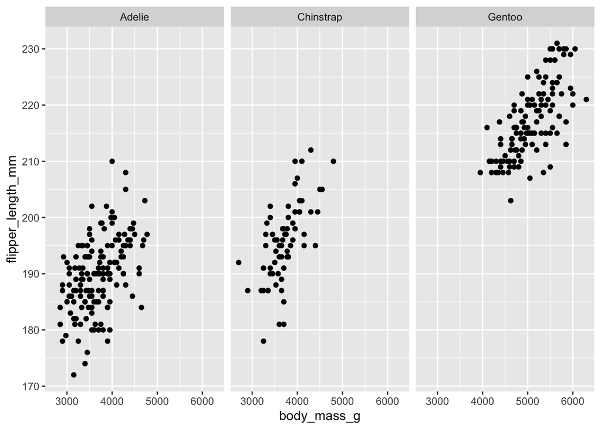

```r
penguins %>% ggplot(aes(x= body_mass_g, y = flipper_length_mm)) + geom_point() +
  facet_wrap( ~ species)
```

Use `scales='free'` (or free_x or free_y) to change the axis scaling and the look of the plots.

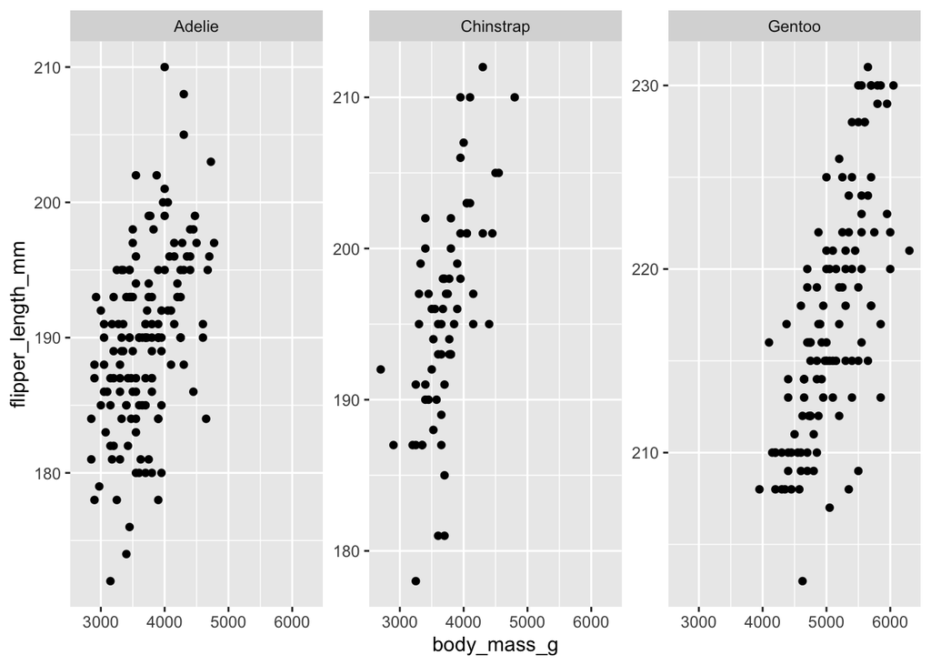

```r
penguins %>% ggplot(aes(x= body_mass_g, y = flipper_length_mm)) + geom_point() +
  facet_wrap( ~ species, scales="free_y")
```

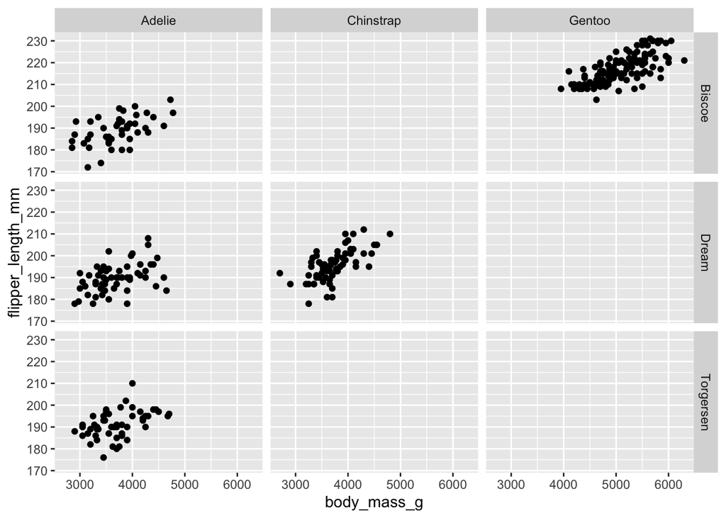

```r
penguins %>% ggplot(aes(x= body_mass_g, y = flipper_length_mm)) + geom_point() +
  facet_grid( island ~ species) # , scales="free_y")
```

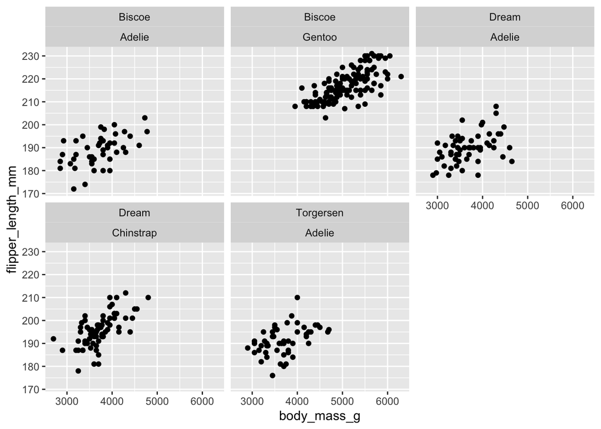

```r
penguins %>% ggplot(aes(x= body_mass_g, y = flipper_length_mm)) + geom_point() +
  facet_wrap( ~ island + species) # , scales="free_y")
```

You can compute statistics separately for each facet. Try `geom_smooth` with a facetted plot.

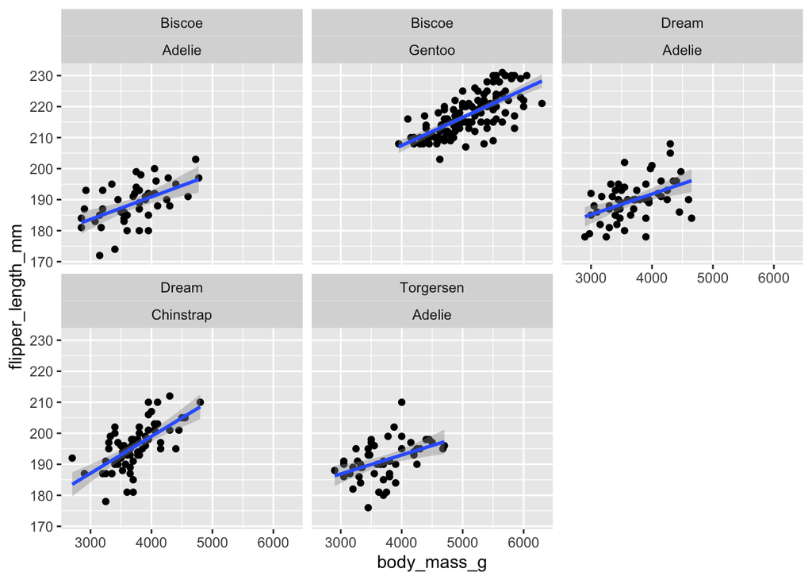

```r
penguins %>% ggplot(aes(x= body_mass_g, y = flipper_length_mm)) + geom_point() +
  facet_wrap( ~ island + species) + #  scales="free")  +
  geom_smooth(method = "lm")
```

Compute means and then plot them using `geom_point` (or to be fancy, `stat_unique` to plot each point only once).

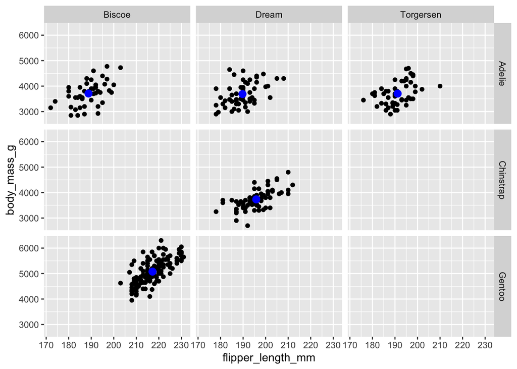

```r
penguins %>%
  group_by(species, island) %>%
  mutate(mean_flipper = mean(flipper_length_mm, na.rm=TRUE),
         mean_body = mean(body_mass_g, na.rm=TRUE)) %>%
  ggplot(aes(flipper_length_mm, body_mass_g)) +
  geom_point() +
  stat_unique(aes(x=mean_flipper, y = mean_body), col="blue", size=3) +
  facet_grid(species ~ island)
```

Compare that plot with what you get when you add a point at the overall mean of x and y on each facet. This computes the mean of the whole dataset, so the same point is shown in blue on each panel.

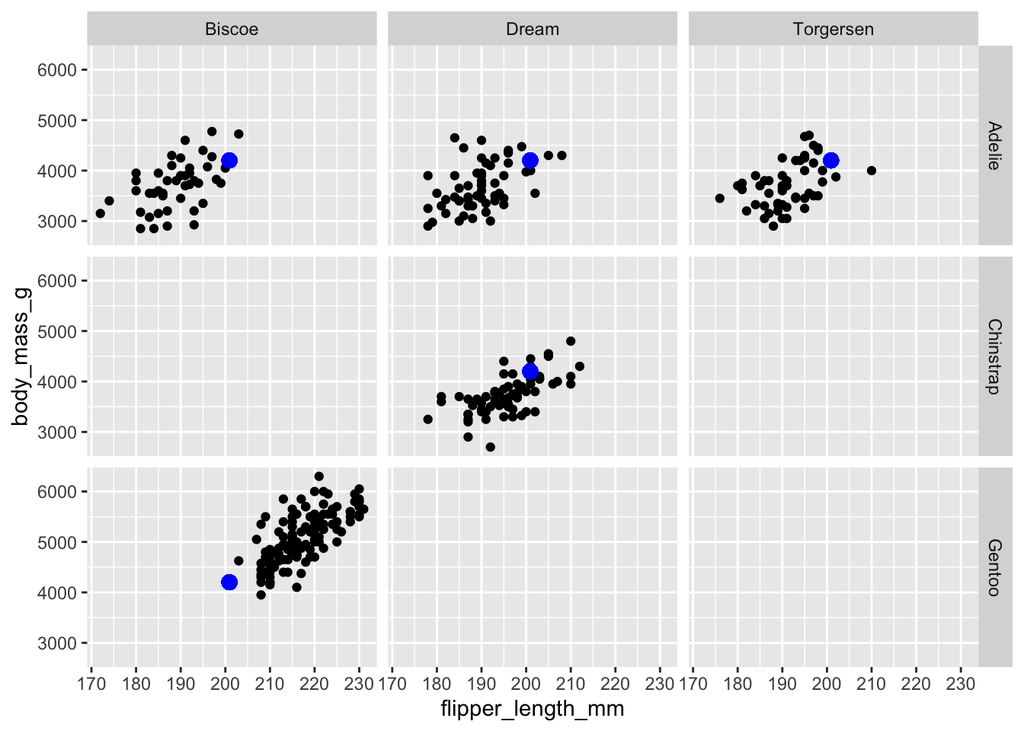

```r
penguins %>% ggplot(aes(flipper_length_mm, body_mass_g)) +
  geom_point() +
  geom_point(aes(x = mean(flipper_length_mm, na.rm=TRUE),
                 y = mean(body_mass_g, na.rm=TRUE)),
             color="blue", size = 3, alpha = 0.5) +
  facet_grid(species ~ island)
```

## Reading data

We can read data from comma separated values files (csv) or worksheet files (xls and xlsx) using `read_csv` and `read_excel` (in the `readxl` package.)

Open a spreadsheet program. Create a new worksheet with some data (a few rows and a few columns at least.) Create at least one categorical variable and one quantitative variable. Leave at least one cell empty to create a missing value. Save the file. Read it in to R. Plot the data.

```r
dt1 <- read_excel("file.xlsx")
```

```
## * `` -> ...4
## * `` -> ...5
```

```r
dt2 <- read_csv("file.csv")
dt2
```

```
## # A tibble: 4 x 3
##   Name    Age Country
##   <chr> <dbl> <chr>
## 1 Li       19 UK
## 2 Bob      22 Canada
## 3 Susan    20 USA
## 4 <NA>     28 Czech
```